# Assignment 3

Pawanjeet Kaur

10/25/2019

### Problem 2: Ex. 14[a-f] (Chapter 3, page 125) [2pt]

### This problem focuses on the collinearity problem.

### (a) Perform the following commands in R: The last line corresponds to creating a linear model in which y is a function of x1 and x2. Write out the form of the linear model. What are the regression coefficients?

```r
  set.seed(1)
  x1=runif(100)
  x2=0.5*x1+rnorm(100)/10
  y=2+2*x1+0.3*x2+rnorm(100)
```

### (b) What is the correlation between x1 and x2? Create a scatterplot displaying the relationship between the variables.

```r
cor(x1, x2)
```

```
## [1] 0.8351212
```

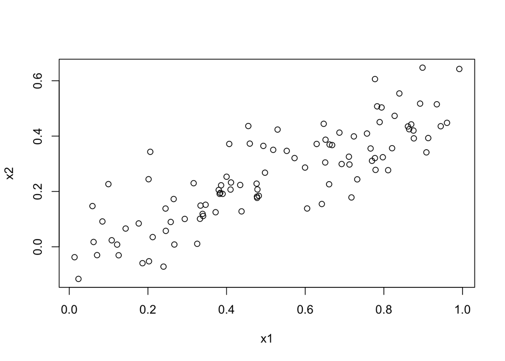

```r
plot(x1, x2)
```

### (c) Using this data, fit a least squares regression to predict y using x1 and x2. Describe the results obtained. What are βˆ0, βˆ1, and βˆ2? How do these relate to the true β0, β1, and β2? Can you reject the null hypothesis H0 : β1 = 0? How about the null hypothesis H0 : β2 = 0?

```r
lm_fit <- lm(y ~ x1 + x2)

summary(lm_fit)
```

```
##
## Call:
## lm(formula = y ~ x1 + x2)
##
## Residuals:
##     Min      1Q  Median      3Q     Max
## -2.8311 -0.7273 -0.0537  0.6338  2.3359
##
## Coefficients:
##             Estimate Std. Error t value Pr(>|t|)
## (Intercept)   2.1305     0.2319   9.188 7.61e-15 ***
## x1            1.4396     0.7212   1.996   0.0487 *
## x2            1.0097     1.1337   0.891   0.3754
## ---
## Signif. codes:  0 '***' 0.001 '**' 0.01 '*' 0.05 '.' 0.1 ' ' 1
##
## Residual standard error: 1.056 on 97 degrees of freedom
## Multiple R-squared:  0.2088, Adjusted R-squared:  0.1925
## F-statistic:  12.8 on 2 and 97 DF,  p-value: 1.164e-05
```

**βˆ1 is 1.4396 ,βˆ2 is 1.0097 , βˆ0 is 2.130. For βˆ1 we reject ho for ha. For β2 we cannot reject null hypothesis.**

### (d) Now fit a least squares regression to predict y using only x1. Comment on your results. Can you reject the null hypothesis H0 :β1 =0?

```r
lm_fit_1 <- lm(y ~ x1)

summary(lm_fit_1)
```

```
##
## Call:
## lm(formula = y ~ x1)
##
## Residuals:
##      Min       1Q   Median       3Q      Max
## -2.89495 -0.66874 -0.07785  0.59221  2.45560
##
## Coefficients:
##             Estimate Std. Error t value Pr(>|t|)
## (Intercept)   2.1124     0.2307   9.155 8.27e-15 ***
## x1            1.9759     0.3963   4.986 2.66e-06 ***
## ---
## Signif. codes:  0 '***' 0.001 '**' 0.01 '*' 0.05 '.' 0.1 ' ' 1
##
## Residual standard error: 1.055 on 98 degrees of freedom
## Multiple R-squared:  0.2024, Adjusted R-squared:  0.1942
## F-statistic: 24.86 on 1 and 98 DF,  p-value: 2.661e-06
```

**As the p-value is less than alpha we can reject null hypothesis.**

### (e) Now fit a least squares regression to predict y using only x2. Comment on your results. Can you reject the null hypothesis H0 :β1 =0?

```r
lm_fit_2 <- lm(y ~ x2)

summary(lm_fit_2)
```

```
##
## Call:
## lm(formula = y ~ x2)
##
## Residuals:
##      Min       1Q   Median       3Q      Max
## -2.62687 -0.75156 -0.03598  0.72383  2.44890
##
## Coefficients:
##             Estimate Std. Error t value Pr(>|t|)
## (Intercept)   2.3899     0.1949   12.26  < 2e-16 ***
## x2            2.8996     0.6330    4.58 1.37e-05 ***
## ---
## Signif. codes:  0 '***' 0.001 '**' 0.01 '*' 0.05 '.' 0.1 ' ' 1
##
## Residual standard error: 1.072 on 98 degrees of freedom
## Multiple R-squared:  0.1763, Adjusted R-squared:  0.1679
## F-statistic: 20.98 on 1 and 98 DF,  p-value: 1.366e-05
```

**As the p-value is less than alpha we can reject ho**

### (f) Do the results obtained in (c)–(e) contradict each other? Explain your answer.

**Yes the results in (c) to (e) contradict as we can see in part c we for β1 we rejected null hypothesis and for β2 we could not reject null hypothesis. Whereas in part d and e we rejected null hypothesis.**

### Problem 3: Ex. 5 (Chapter 4, page 169) [1pt]

### **We now examine the differences between LDA and QDA**

### a) If the Bayes decision boundary is linear, do we expect LDA or QDA to perform better on the training set? On the test set?

**In QDA on test data the bias will decrease hence, QDA will perform better than LDA.Whereas if the Bayes decision boundary is linear, we know LDA has linear decision boundary hence LDA will perform better than QDA.**

### (b) If the Bayes decision boundary is non-linear, do we expect LDA or QDA to perform better on the training set? On the test set?

**If bayes decision boundary is non linear, we can say QDA will perform better on both training and test sets**

### (c) In general, as the sample size n increases, do we expect the test prediction accuracy of QDA relative to LDA to improve, decline, or be unchanged? Why?

**With increase in the sample size the accuracy of QDA will improve.As we know with increase in sample size for non linear methods the bias will decrease along with the variance of models.**

### (d) True or False: Even if the Bayes decision boundary for a given problem is linear, we will probably achieve a superior test error rate using QDA rather than LDA because QDA is flexible enough to model a linear decision boundary. Justify your answer.

**False, for small value QDA is more prone to errors and add noise to model. Hence test errors in QDA will be high. So, LDA performs better in such scenario and given statement is false.**

### Problem 4: Ex. 6 (Chapter 4, page 170) [1pt]

```r
library(ISLR)
dim(Weekly)
```

```
## [1] 1089    9
```

```r
str(Weekly)
```

```
## 'data.frame':    1089 obs. of  9 variables:
##  $ Year     : num  1990 1990 1990 1990 1990 1990 1990 1990 1990 1990 ...
##  $ Lag1     : num  0.816 -0.27 -2.576 3.514 0.712 ...
##  $ Lag2     : num  1.572 0.816 -0.27 -2.576 3.514 ...
##  $ Lag3     : num  -3.936 1.572 0.816 -0.27 -2.576 ...
##  $ Lag4     : num  -0.229 -3.936 1.572 0.816 -0.27 ...
##  $ Lag5     : num  -3.484 -0.229 -3.936 1.572 0.816 ...
##  $ Volume   : num  0.155 0.149 0.16 0.162 0.154 ...
##  $ Today    : num  -0.27 -2.576 3.514 0.712 1.178 ...
##  $ Direction: Factor w/ 2 levels "Down","Up": 1 1 2 2 2 1 2 2 2 1 ...
```

### (a) Produce some numerical and graphical summaries of the Weekly data.Do there appear to be any patterns?

```r
summary(Weekly)
```

```
##       Year           Lag1               Lag2               Lag3
##  Min.   :1990   Min.   :-18.1950   Min.   :-18.1950   Min.   :-18.1950
##  1st Qu.:1995   1st Qu.: -1.1540   1st Qu.: -1.1540   1st Qu.: -1.1580
##  Median :2000   Median :  0.2410   Median :  0.2410   Median :  0.2410
##  Mean   :2000   Mean   :  0.1506   Mean   :  0.1511   Mean   :  0.1472
##  3rd Qu.:2005   3rd Qu.:  1.4050   3rd Qu.:  1.4090   3rd Qu.:  1.4090
##  Max.   :2010   Max.   : 12.0260   Max.   : 12.0260   Max.   : 12.0260
##       Lag4               Lag5              Volume
##  Min.   :-18.1950   Min.   :-18.1950   Min.   :0.08747
##  1st Qu.: -1.1580   1st Qu.: -1.1660   1st Qu.:0.33202
##  Median :  0.2380   Median :  0.2340   Median :1.00268
##  Mean   :  0.1458   Mean   :  0.1399   Mean   :1.57462
##  3rd Qu.:  1.4090   3rd Qu.:  1.4050   3rd Qu.:2.05373
##  Max.   : 12.0260   Max.   : 12.0260   Max.   :9.32821
##      Today          Direction
##  Min.   :-18.1950   Down:484
##  1st Qu.: -1.1540   Up  :605
##  Median :  0.2410
##  Mean   :  0.1499
##  3rd Qu.:  1.4050
##  Max.   : 12.0260
```

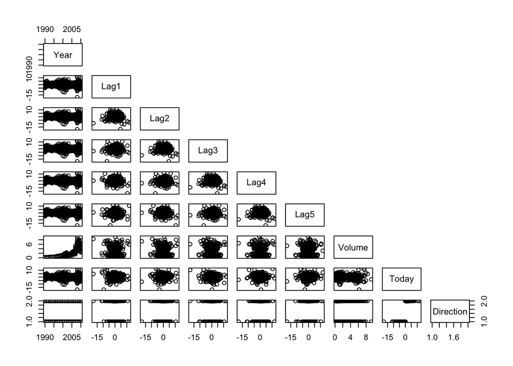

```r
pairs(Weekly, upper.panel = NULL)
```

```r
# Corelation between different variables
cor(Weekly[,-9])[1,]
```

```
##        Year        Lag1        Lag2        Lag3        Lag4        Lag5
##  1.00000000 -0.03228927 -0.03339001 -0.03000649 -0.03112792 -0.03051910
##      Volume       Today
##  0.84194162 -0.03245989
```

**Volume is highly correlated with year**

### (b) Use the full data set to perform a logistic regression with Direction as the response and the five lag variables plus Volume as predictors. Use the summary function to print the results.Do any of the predictors appear to be statistically significant? If so, which ones?

```r
log_fit <- glm(Direction ~ Lag1 + Lag2 + Lag3 + Lag4 + Lag5 + Volume, data = Weekly,family = "binomial")

summary(log_fit)
```

```
##
## Call:
## glm(formula = Direction ~ Lag1 + Lag2 + Lag3 + Lag4 + Lag5 +
##     Volume, family = "binomial", data = Weekly)
##
## Deviance Residuals:
##     Min       1Q   Median       3Q      Max
## -1.6949  -1.2565   0.9913   1.0849   1.4579
##
## Coefficients:
##             Estimate Std. Error z value Pr(>|z|)
## (Intercept)  0.26686    0.08593   3.106   0.0019 **
## Lag1        -0.04127    0.02641  -1.563   0.1181
## Lag2         0.05844    0.02686   2.175   0.0296 *
## Lag3        -0.01606    0.02666  -0.602   0.5469
## Lag4        -0.02779    0.02646  -1.050   0.2937
## Lag5        -0.01447    0.02638  -0.549   0.5833
## Volume      -0.02274    0.03690  -0.616   0.5377
## ---
## Signif. codes:  0 '***' 0.001 '**' 0.01 '*' 0.05 '.' 0.1 ' ' 1
##
## (Dispersion parameter for binomial family taken to be 1)
##
##     Null deviance: 1496.2  on 1088  degrees of freedom
## Residual deviance: 1486.4  on 1082  degrees of freedom
## AIC: 1500.4
##
## Number of Fisher Scoring iterations: 4
```

**Lag2 is statisitically significant**

### (c) Compute the confusion matrix and overall fraction of correct predictions.Explain what the confusion matrix is telling you about the types of mistakes made by logistic regression.

```r
prediction <- predict(log_fit, type= "response")
prediction <- ifelse(prediction >= 0.5, 'Up', 'Down')

conf_matrix <- table(prediction , Weekly$Direction)

accuracy_logistic_1 <- sum(diag(conf_matrix))/sum(conf_matrix)
accuracy_logistic_1
```

```
## [1] 0.5610652
```

### (d) Now fit the logistic regression model using a training data period from 1990 to 2008, with Lag2 as the only predictor.Compute the confusion matrix and the overall fraction of correct predictions for the held out data (that is, the data from 2009 and 2010).

```r
summary(Weekly$Year)
```

```
##    Min. 1st Qu.  Median    Mean 3rd Qu.    Max.
##    1990    1995    2000    2000    2005    2010
```

```r
train_data <- Weekly[Weekly$Year <= 2008,]
test_data <- Weekly[Weekly$Year > 2008,]

log_fit_2 <- glm(Direction ~ Lag2 , data = train_data , family = 'binomial')

summary(log_fit_2)
```

```
##
## Call:
## glm(formula = Direction ~ Lag2, family = "binomial", data = train_data)
##
## Deviance Residuals:
##    Min      1Q  Median      3Q     Max
## -1.536  -1.264   1.021   1.091   1.368
##
## Coefficients:
##             Estimate Std. Error z value Pr(>|z|)
## (Intercept)  0.20326    0.06428   3.162  0.00157 **
## Lag2         0.05810    0.02870   2.024  0.04298 *
## ---
## Signif. codes:  0 '***' 0.001 '**' 0.01 '*' 0.05 '.' 0.1 ' ' 1
##
## (Dispersion parameter for binomial family taken to be 1)
##
##     Null deviance: 1354.7  on 984  degrees of freedom
## Residual deviance: 1350.5  on 983  degrees of freedom
## AIC: 1354.5
##
## Number of Fisher Scoring iterations: 4
```

```r
pred_log_fit_2 <- predict(log_fit_2, newdata = test_data , type = 'response')
pred_log_fit_2 <- ifelse(pred_log_fit_2 >= 0.5 , 'Up', 'Down')
pred_log_fit_2
```

[output not shown]

```r
conf_matrix_2 <- table(pred_log_fit_2 , test_data$Direction)
accuracy_logisitic_2 <- sum(diag(conf_matrix_2))/sum(conf_matrix_2)

accuracy_logisitic_2
```

```
## [1] 0.625
```

### (e) Repeat (d) using LDA.

```r
require('MASS')
lda_model <- lda(Direction ~ Lag2, data = train_data)

summary(lda_model)
```

```
##         Length Class  Mode
## prior   2      -none- numeric
## counts  2      -none- numeric
## means   2      -none- numeric
## scaling 1      -none- numeric
## lev     2      -none- character
## svd     1      -none- numeric
## N       1      -none- numeric
## call    3      -none- call
## terms   3      terms  call
## xlevels 0      -none- list
```

```r
pred_lda <- predict(lda_model, newdata = test_data)
conf_matrix_3 <- table(pred_lda$class , test_data$Direction)

accuracy_lda <- sum(diag(conf_matrix_3))/sum(conf_matrix_3)
accuracy_lda
```

```
## [1] 0.625
```

### (f) Repeat (d) using QDA.

```r
qda_model_10 <- qda(Direction ~ Lag2 , data = train_data)
summary(qda_model_10)
```

```
##         Length Class  Mode
## prior   2      -none- numeric
## counts  2      -none- numeric
## means   2      -none- numeric
## scaling 2      -none- numeric
## ldet    2      -none- numeric
## lev     2      -none- character
## N       1      -none- numeric
## call    3      -none- call
## terms   3      terms  call
## xlevels 0      -none- list
```

```r
pred_qda <- predict(qda_model_10 , newdata = test_data)
conf_matrix_4 <- table(pred_qda$class , test_data$Direction)
accuracy_qda <- sum(diag(conf_matrix_4))/sum(conf_matrix_4)
accuracy_qda
```

```
## [1] 0.5865385
```

### (g) Repeat (d) using KNN with K = 1.

```r
require(class)
knn_1 <- knn(train = data.frame(train_data$Lag2), test = data.frame(test_data$Lag2), cl = train_data$Direction , k=1)

conf_matrix_5 <- table(knn_1 , test_data$Direction)
conf_matrix_5
```

```
##
## knn_1  Down Up
##   Down   21 30
##   Up     22 31
```

```r
accuracy_knn = sum(diag(conf_matrix_5))/sum(conf_matrix_5)
accuracy_knn
```

```
## [1] 0.5
```

### (h) Which of these methods appears to provide the best results on this data?

```r
# Accuracy of logisitic model with all variables
accuracy_logistic_1
```

```
## [1] 0.5610652
```

```r
# Accuracy of logisitic model with statisitically significant variables
accuracy_logisitic_2
```

```
## [1] 0.625
```

```r
# Accuracy of lda
accuracy_lda
```

```
## [1] 0.625
```

```r
# Accuracy of qda
accuracy_qda
```

```
## [1] 0.5865385
```

```r
# Accuracy of knn
accuracy_knn
```

```
## [1] 0.5
```

### i) Experiment with different combinations of predictors, including possible transformations and interactions, for each of the methods. Report the variables, method, and associated confusion matrix that appears to provide the best results on the held out data. Note that you should also experiment with values for K in the KNN classifier.

```r
glm_fit_transform <- glm( Direction ~ Lag2+I(Lag2^2)+I(Lag2^3),data = train_data, family = "binomial")
summary(glm_fit_transform)
```

```
##
## Call:
## glm(formula = Direction ~ Lag2 + I(Lag2^2) + I(Lag2^3), family = "binomial",
##     data = train_data)
##
## Deviance Residuals:
##    Min      1Q  Median      3Q     Max
## -2.194  -1.245   1.008   1.108   1.142
##
## Coefficients:
##              Estimate Std. Error z value Pr(>|z|)
## (Intercept) 0.1608285  0.0714552   2.251   0.0244 *
## Lag2        0.0491970  0.0340597   1.444   0.1486
## I(Lag2^2)   0.0095243  0.0072076   1.321   0.1864
## I(Lag2^3)   0.0005092  0.0005445   0.935   0.3497
## ---
## Signif. codes:  0 '***' 0.001 '**' 0.01 '*' 0.05 '.' 0.1 ' ' 1
##
## (Dispersion parameter for binomial family taken to be 1)
##
##     Null deviance: 1354.7  on 984  degrees of freedom
## Residual deviance: 1348.5  on 981  degrees of freedom
## AIC: 1356.5
##
## Number of Fisher Scoring iterations: 4
```

```r
pred_glm_fit_transf <- predict(glm_fit_transform, newdata = test_data , type = 'response')
pred_glm_fit_transf <- ifelse(pred_glm_fit_transf >= 0.5 , 'Up', 'Down')

conf_matrix_glm_transf <- table(pred_glm_fit_transf , test_data$Direction)
accuracy_logisitic_glm_transf <- sum(diag(conf_matrix_glm_transf))/sum(conf_matrix_glm_transf)

accuracy_logisitic_glm_transf
```

```
## [1] 0.4134615
```

```r
# Square Root
glm_fit_sqrt <- glm(Direction~sqrt(abs(Lag2)),data = train_data, family = "binomial")
summary(glm_fit_sqrt)
```

```
##
## Call:
## glm(formula = Direction ~ sqrt(abs(Lag2)), family = "binomial",
##     data = train_data)
##
## Deviance Residuals:
##    Min      1Q  Median      3Q     Max
## -1.405  -1.263   1.058   1.093   1.136
##
## Coefficients:
##                 Estimate Std. Error z value Pr(>|z|)
## (Intercept)      0.09488    0.15028   0.631    0.528
## sqrt(abs(Lag2))  0.09961    0.11788   0.845    0.398
##
## (Dispersion parameter for binomial family taken to be 1)
##
##     Null deviance: 1354.7  on 984  degrees of freedom
## Residual deviance: 1354.0  on 983  degrees of freedom
## AIC: 1358
##
## Number of Fisher Scoring iterations: 3
```

```r
pred_glm_fit_sqrt <- predict(glm_fit_sqrt, newdata = test_data , type = 'response')
pred_glm_fit_sqrt <- ifelse(pred_glm_fit_sqrt >= 0.5 , 'Up', 'Down')

conf_matrix_glm_sqrt <- table(pred_glm_fit_sqrt , test_data$Direction)
accuracy_logisitic_glm_sqrt <- sum(diag(conf_matrix_glm_sqrt))/sum(conf_matrix_glm_sqrt)

accuracy_logisitic_glm_sqrt
```

```
## [1] 0.4134615
```

```r
# Interaction Effect
glm_fit_int <- glm(Direction~ Lag2*Lag1,data = train_data, family = "binomial")
summary(glm_fit_int)
```

```
##
## Call:
## glm(formula = Direction ~ Lag2 * Lag1, family = "binomial", data = train_data)
##
## Deviance Residuals:
##    Min      1Q  Median      3Q     Max
## -1.573  -1.259   1.003   1.086   1.596
##
## Coefficients:
##              Estimate Std. Error z value Pr(>|z|)
## (Intercept)  0.211419   0.064589   3.273  0.00106 **
## Lag2         0.053471   0.029193   1.832  0.06700 .
## Lag1        -0.051505   0.030727  -1.676  0.09370 .
## Lag2:Lag1    0.001921   0.007460   0.257  0.79680
## ---
## Signif. codes:  0 '***' 0.001 '**' 0.01 '*' 0.05 '.' 0.1 ' ' 1
##
## (Dispersion parameter for binomial family taken to be 1)
##
##     Null deviance: 1354.7  on 984  degrees of freedom
## Residual deviance: 1346.9  on 981  degrees of freedom
## AIC: 1354.9
##
## Number of Fisher Scoring iterations: 4
```

```r
pred_glm_fit_int <- predict(glm_fit_int, newdata = test_data , type = 'response')
pred_glm_fit_int <- ifelse(pred_glm_fit_int >= 0.5 , 'Up', 'Down')

conf_matrix_glm_int <- table(pred_glm_fit_int , test_data$Direction)
accuracy_logisitic_glm_int <- sum(diag(conf_matrix_glm_int))/sum(conf_matrix_glm_int)

accuracy_logisitic_glm_int
```

```
## [1] 0.5769231
```

```r
str(train_data)
```

```
## 'data.frame':    985 obs. of  9 variables:
##  $ Year     : num  1990 1990 1990 1990 1990 1990 1990 1990 1990 1990 ...
##  $ Lag1     : num  0.816 -0.27 -2.576 3.514 0.712 ...
##  $ Lag2     : num  1.572 0.816 -0.27 -2.576 3.514 ...
##  $ Lag3     : num  -3.936 1.572 0.816 -0.27 -2.576 ...
##  $ Lag4     : num  -0.229 -3.936 1.572 0.816 -0.27 ...
##  $ Lag5     : num  -3.484 -0.229 -3.936 1.572 0.816 ...
##  $ Volume   : num  0.155 0.149 0.16 0.162 0.154 ...
##  $ Today    : num  -0.27 -2.576 3.514 0.712 1.178 ...
##  $ Direction: Factor w/ 2 levels "Down","Up": 1 1 2 2 2 1 2 2 2 1 ...
```

```r
train_knn_X <- data.frame(train_data[,3])
train_knn_Y <- data.frame(train_data[,9])

dim(train_knn_X)
```

```
## [1] 985   1
```

```r
dim(train_knn_Y)
```

```
## [1] 985   1
```

```r
test_knn_X <- data.frame(test_data[,3])
test_knn_Y <- data.frame(test_data[,9])

dim(test_knn_X)
```

```
## [1] 104   1
```

```r
dim(test_knn_Y)
```

```
## [1] 104   1
```

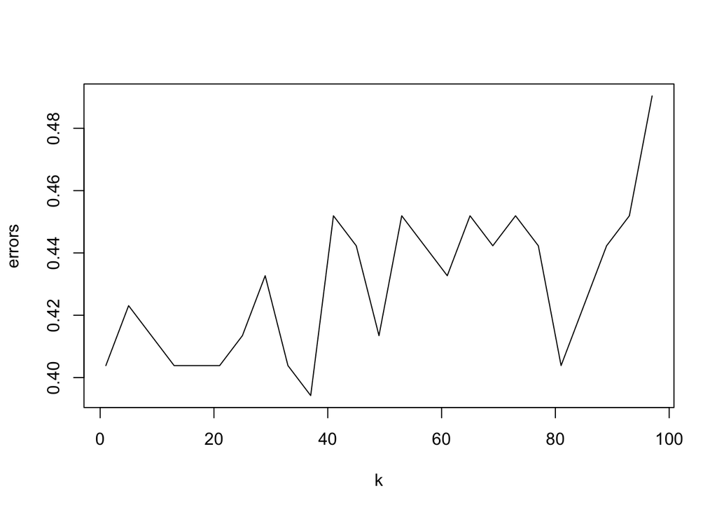

```r
errors <- c()
maxK <- 100
step_k <- 4

for(j in seq(1,maxK,step_k)){
  knn_run <- knn(train = data.frame(train_data$Lag2), test = data.frame(test_data$Lag2), cl = train_data$Direction,k = j)
  pred <- table(knn_run,test_data$Direction)
  acc <- sum(diag(pred))/sum(pred)
  errors <- c(1-acc , errors)
}

data <- cbind(seq(1,maxK,step_k),errors)

plot(data,type="l",xlab="k")
```